# R Worksheet 8: Discrete random variables

MATH1710 Probability and Statistcs I

University of Leeds, 2021–22

*This R worksheet does not include assessed questions.You should complete this worksheet in Week 8. If you have difficulty with this worksheet, you can get help at the office hours drop-in sessions.*

On the last worksheet, we looked at dealing with famous discrete random variables: the binomial, geometric, and Poisson distributions. In this worksheet, we will look at dealing with arbitrary discrete random variables, as defined by a probability mass function (PMF)

## Probability mass function

The key to dealing with a discrete random variable is to set up two things: the range of values the random variable can take, and the PMF itself.

Consider, for example, the following PMF for a random variable $X$:

| $x$ | $0$ | $0.5$ | $1$ | $2$ | $2.5$ | $4$ |
| --- | --- | --- | --- | --- | --- | --- |
| $p_X(x)$ | $0.1$ | $0.2$ | $0.2$ | $0.3$ | $0.1$ | $0.1$ |

We want to store the $x$ values in one vector, and the $p_X(x)$ values in another vector. We can do that like this:

```r
x <- c(0, 0.5, 1, 2, 2.5, 4)
pmf_x <- c(0.1, 0.2, 0.2, 0.3, 0.1, 0.1)
```

It’s good practice to check that the PMF does indeed sum to 1:

```r
sum(pmf_x)
```

```
## [1] 1
```

We can find the probability of a given value of $x$ by pulling out the relevant value of the PMF. We are used to using square brackets to pull out the elements of a vector. But more complicate expressions can be put inside the brackets, like this:

- `pmf_x[x == 0.5]` pulls out the value of the PMF that corresponds to $x = 0.5$; that is, of $p_X(0.5)$. (Note the double-equals `==`. Roughly speaking, in R, a single-equals `=` means “is set to be equal to”, while a double-equals `==` means “*is* equal to”.)
- `pmf_x[x > 1.5]` pulls out all the values of the PMF that corresponding to $x > 1.5$. It’s often helpful to use this together with the `sum()` function, because `sum(pmf_x[x > 1.5])` will give $\mathbb P(X > 1.5)$. (Do you see why?)
- Relations that can be used this way are
  - `==`: equals $=$
  - `>`: greater than $>$
  - `<`: less than $>$
  - `>=`: greater than or equal to $\geq$
  - `<=`: less than or equal to $\leq$
  - Keen R users may wish to research use of `!=`, `in`, `&`, `|`.

> **Exercise 8.1.** Let $Y$ be the sum of fair dice rolls. So $Y$ takes the values $(2, 3, \dots, 12)$ with probabilities $\frac{1}{36}(1,2,3,4,5,6,5,4,3,2,1)$.  
> **(a)** Enter this random variable into `y` and `pmf_y`. Do so as efficiently as possible, by taking advantage of the colon notation.  
> **(b)** What is $\mathbb P(Y = 9)$?  
> **(c)** What is $\mathbb P(Y \leq 6)$?

## Plotting a PMF

If we want to plot a picture of a PMF (like those in the Section 6 of the notes) we can use `plot()` together with the optional argument `type = "h"`. Here, `"h"` stands for “**h**istogram-like vertical lines”, which are most appropriate for displaying PMFs. I also like to make the lines somewhat thicker, with the `lwd = ...` argument, and make sure that the y-axis starts from 0.

So I would draw a graph for our previous PMF like this:

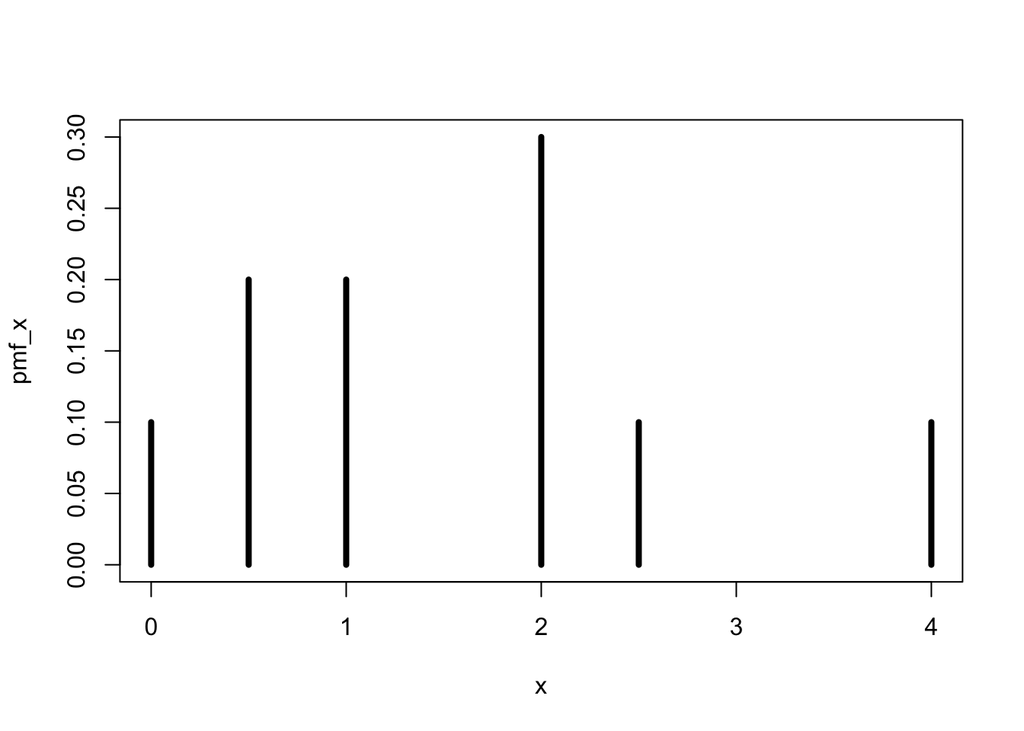

```r
plot(x, pmf_x, type = "h", lwd = 4, ylim = c(0, max(pmf_x)))
```

> **Exercise 8.2.** Draw a plot of the PMF for the dice random variable $Y$ from Exercise 8.1. Draw the lines in blue. Make sure to label the axes appropriately.

## Cumulative distribution function

So taking the cumulative sum of the PMF,

```r
cumsum(pmf_x)
```

```
## [1] 0.1 0.3 0.5 0.8 0.9 1.0
```

gives a vector of the values of the CDF at the values of $x$.

However, the CDF also should be defined in between the values of $x$ in the range of $X$, where it should behave like a “step function”. We can create such a function using the **`stepfun()`** function. This `stepfun` requires two arguments:

- $n$ places where the step function jumps. In our case, this is the set of values $x$ the random variable can take
- $n+1$ values of the step function between those jumps, including below the first jump and after the last jump. In our case, this is 0 below the first value of $x$, then the values of the cumulative sum we have just discussed.

So we form the CDF function with

```r
cdf_x <- stepfun(x, c(0, cumsum(pmf_x)))
```

We can test that this CDF works between the values in the range of $X$ by testing it:

```r
cdf_x(1.62)
```

```
## [1] 0.5
```

We can also plot the CDF with the `plot()` function:

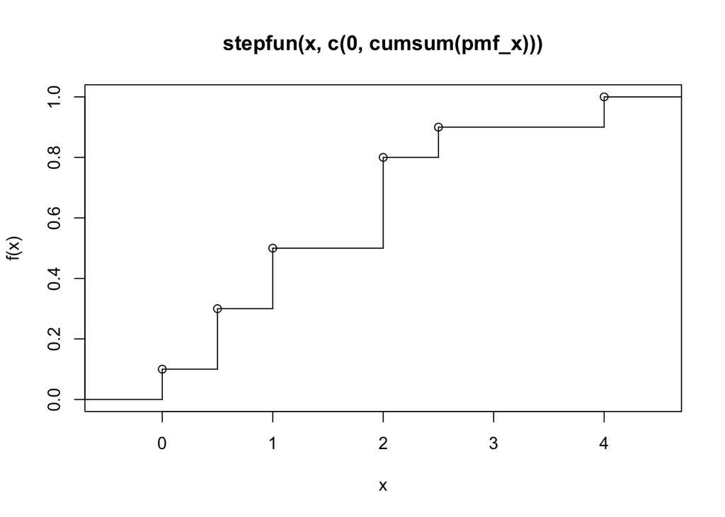

```r
plot(cdf_x)
```

with other extra graphical commands, as required. The “blobs” are to let the reader know that *at* the jumps, the function takes the higher value.

> **Exercise 8.3.** Form the CDF for the dice random variable from Exercise 8.1.  
> **(a)** What is $F_Y(4.6)$?  
> **(b)** What is $\mathbb P(Y > 8.2)$?  
> **(c)** Plot the CDF. Make sure to label your axes appropriately.

## Expectation

Recall that the definition of the expectation of a discrete random variable is
$$\mathbb EX = \sum_x x\, p(x) .$$

So to calculate this, we can simply use R’s `sum()` function. We just want

```r
exp_x <- sum(x * pmf_x)
exp_x
```

```
## [1] 1.55
```

That’s all there is to it!

> **Exercise 8.4.** With the dice random variable again:  
> **(a)** Calculate the expectation $\mathbb EY$.  
> **(b)** Calculate $\mathbb EY^2$.  
> **(c)** Using parts (a) and (b), find the variance of $Y$.

## Sampling from a distribution

Finally, we may wish to sample from a discrete random variable. To do this, we will use the **`sample()`** function, like this:

```r
sample(x, 20, replace = TRUE, prob = pmf_x)
```

```
##  [1] 2.0 2.0 0.0 2.0 2.0 0.5 0.0 2.0 0.5 2.0 2.0 1.0 0.0 2.0 2.0 0.5 2.5 1.0 2.0 1.0
```

Here, the arguments are:

1. The first argument is the set of values to be sampled, which for us is the range of the random variable.
2. The second argument is the number of samples we wish to take. In the above example, we took 20 samples.
3. `replace = TRUE` tells us we want to be allowed “repeats” in our sample. If we want IID samples of a random variable, we always want sampling with replacement. (For some sampling-without-replacement probabiltiy problems, it might be approriate to take `replace = FALSE`, which is R’s default for the `sample()` function.)
4. `prob = ...` tells R with what probabilities each value of `x` should be sampled. If this argument is omitted, R takes each value to be equally likely.

> **Exercise 8.5.** Sample 10,000 simulated dice rolls from the random variable $Y$. Calculate the mean of these simulations. Compare your answer with that from Exercise 8.4(a), and explain why you got the answer you did, using results from the module.